# Data Prep

Author

Eva, Utku, Özge

## 1 Setup: load packages and scripts

```r
# packages
invisible(lapply(c("dplyr", "ggplot2", "tidyr", "readr", "purrr", "stringr", "knitr", "dplyr", "gt"), library, character.only = TRUE))


# load scripts
invisible(lapply(list.files("./scripts", "\\.R$", full.names = TRUE), source))
```

## 2 Load the data

- Read in the experimental data
- First participant is also included now.
- It is okay to have undefineds and everything given that this is the entire raw results.

```r
fname <- "./data/freq_sa_june2.csv"
df <- get.ibex(fname)
glimpse(df)
```

```
Rows: 32,657
Columns: 26
$ Results.reception.time               <int> 1745071852, 1745071852, 174507185…
$ MD5.hash.of.participant.s.IP.address <chr> "c98e53191c8d693e1c1b81baf628bc22…
$ Controller.name                      <chr> "PennController", "PennController…
$ Order.number.of.item                 <int> 3, 3, 3, 3, 4, 4, 4, 4, 4, 4, 4, …
$ Inner.element.number                 <int> 0, 0, 0, 0, 0, 0, 0, 0, 0, 0, 0, …
$ Label                                <chr> "instructions", "instructions", "…
$ Latin.Square.Group                   <chr> "NULL", "NULL", "NULL", "NULL", "…
$ PennElementType                      <chr> "PennController", "PennController…
$ PennElementName                      <chr> "0", "0", "0", "0", "1", "1", "1"…
$ Parameter                            <chr> "_Trial_", "_Header_", "_Header_"…
$ Value                                <chr> "Start", "Start", "End", "End", "…
$ EventTime                            <dbl> 1.745071e+12, 1.745071e+12, 1.745…
$ ratingRT                             <chr> "undefined", "undefined", "undefi…
$ questionRT                           <chr> "undefined", "undefined", "undefi…
$ correctAnswer                        <chr> "undefined", "undefined", "undefi…
$ condition                            <chr> "undefined", "undefined", "undefi…
$ answer                               <chr> "undefined", "undefined", "undefi…
$ question                             <chr> "undefined", "undefined", "undefi…
$ conj2                                <chr> "undefined", "undefined", "undefi…
$ conj1                                <chr> "undefined", "undefined", "undefi…
$ type                                 <chr> "undefined", "undefined", "undefi…
$ sentence                             <chr> "undefined", "undefined", "undefi…
$ trialNum                             <chr> "undefined", "undefined", "undefi…
$ itemNum                              <chr> "undefined", "undefined", "undefi…
$ completionCode                       <chr> "CO439307", "CO439307", "CO439307…
$ Comments                             <chr> "NULL", "NULL", "NULL", "NULL", "…
```

```r
df_fp <- get.ibex("./data/freq_sa_june2_firstparticipant.csv")
```

## 3 Demographics

- Extract the forms and the demographic parts
- change %2C to comma, an ecoding error

```r
# forms
forms <- df %>%
  filter(Label == "demo" & PennElementType == "TextInput" & Parameter == "Final") %>%
  select(completionCode, PennElementName, Value) %>%
  pivot_wider(names_from = PennElementName, values_from = Value)

forms_fp <- df_fp %>%
  filter(Label == "demo" & PennElementType == "TextInput" & Parameter == "Final") %>%
  select(completionCode, PennElementName, Value) %>%
  pivot_wider(names_from = PennElementName, values_from = Value)

forms <- bind_rows(forms, forms_fp)
forms[] <- lapply(forms, function(x) if (is.character(x)) gsub("%2C", ",", x) else x)


gt(forms) %>%   opt_interactive(page_size_default = 5)
```

| completionCode | age | language | otherlg | school |
| --- | --- | --- | --- | --- |
| CO439307 | 29 | Türkçe | Türkçe İngilizce | Yüksek Lisans |
| CO695316 | 28 | Türkçe | İngilizce | Yüksek Lisans |
| CO448745 | 29 | TR | ENG | LİSANS |
| CO202632 | 29 | Türkçe | İngilizce, İspanyolca | Lisans mezunu |
| CO16811 | 24 | türkçe | ingilizce | lisans |
| CO703295 | 25 | Türkçe | İngilizce | Lisans |
| CO745806 | 21 | Türkçe | İngilizce | Üniversite |
| CO606387 | 22 | Türkçe | İngilizce | Lisans |
| CO520146 | 32 | Türkçe | İngilizce | Lisans |
| CO470488 | 53 | Türkçe | İngilizce, Fransızca | Doktora |

[output cut: 37 more lines]

## 4 Experimental data

- Assign the conditions
- get suspended affixation conditions
- get suffix type
- get numeric ratings
- Filter out the experimental data
  - RT Cutoff: 2.5sd above the mean
  - Filler Accuracy Cutoff: at least 0.7 accuracy

**Some Problems** (do we really need to do this, maybe…)

- Due to an error in the experiment coding, some of the fillers, specifically the ones that have questions do not have any RT data, including both question RT and rating RT.
- It is possible to recover them using the EventTime column. I have not included it yet, but pseudo-code should be as the following:
- For every participant
  - For every item
    - If the item is a filler with a question
      - Get the EventTime for the question presentation, let it be x
      - Get the EventTime for their answer, let it be y
      - questionRT is y-x in linux time.
      - Get the EventTime for the rating presentation, let it be z
      - Get the EventTime for their rating, let it be w
      - ratingRT is w-z in linux time.

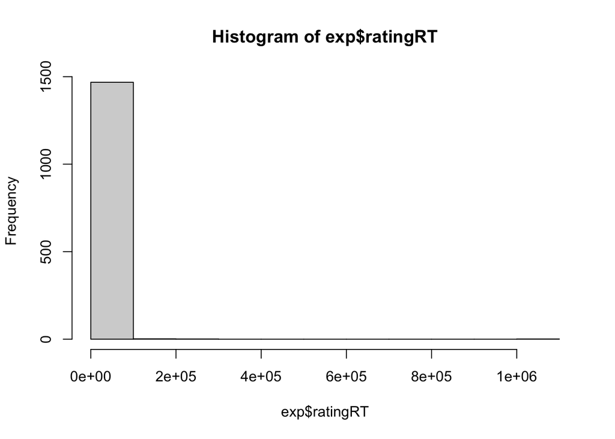

```r
# condition list
condition_labels <- c(
  "a" = "X-and-Y-ci",
  "b" = "X-ci-and-Y-ci",
  "c" = "X-and-Y-li",
  "d" = "X-li-and-Y-li",
  "e" = "X-and-Y-siz",
  "f" = "X-siz-and-Y-siz",
  "g" = "X-and-Y-lik",
  "h" = "X-lik-and-Y-lik"
)

condition_levels <- unname(condition_labels)
# experimental items
exp <- df %>%
  filter(Label == "exp" & PennElementType == "Scale") %>%
  select(completionCode, trialNum, itemNum, condition, Value, sentence, conj1, conj2, ratingRT) %>%
  mutate(
    condition = recode(condition, !!!condition_labels),
    condition = factor(condition, levels = condition_levels),
    ratingRT = as.numeric(ratingRT)
  )

exp_fp <- df_fp %>%
  filter(Label == "exp" & PennElementType == "Scale") %>%
  select(completionCode, trialNum, itemNum, condition, Value, sentence, conj1, conj2) %>%
  mutate(
    condition = recode(condition, !!!condition_labels),
    condition = factor(condition, levels = condition_levels),
    ratingRT = NA
  )


#Ozge: I remove 2.5sd above the mean, this leads to the removal of 10 data points
#the max in this case is a bit over 1 min, I think this is good
hist(exp$ratingRT)
```

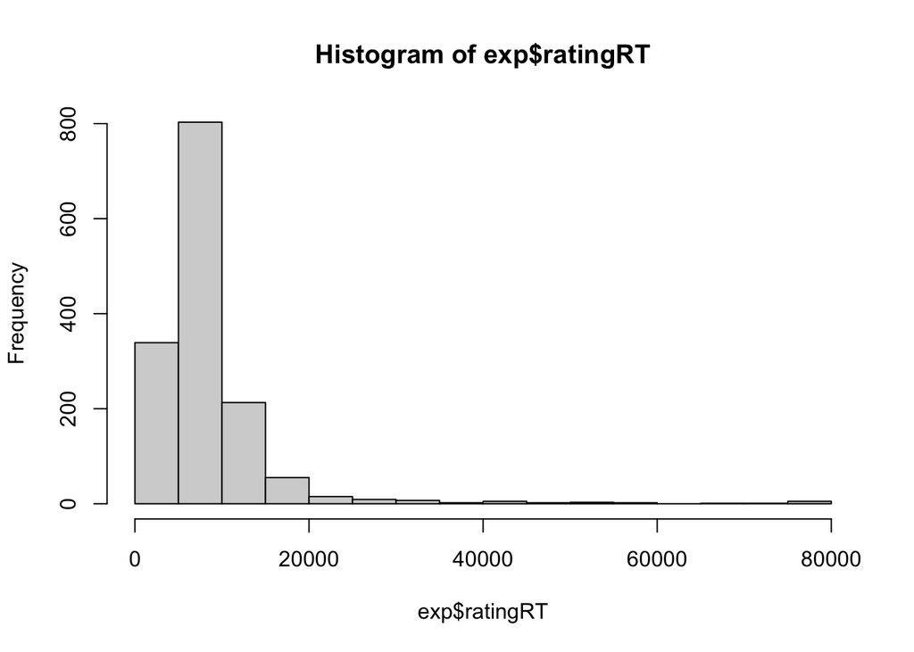

```r
cutoff.RT <- mean(exp$ratingRT) + 2.5*sd(exp$ratingRT)
total_rows <- nrow(exp)
rows_to_remove <- sum(exp$ratingRT > cutoff.RT)
percent_lost <- (rows_to_remove / total_rows) * 100

exp <- exp %>%
  filter(ratingRT <= cutoff.RT)

hist(exp$ratingRT)
```

```r
max(exp$ratingRT) #max is 79k ms, a bit over a min, this seems fine
```

```
[1] 79681
```

```r
exp <- bind_rows(exp, exp_fp)

#Utku: stricter rt cut off
#rt_cutoff <- 10000 # check how many participants on RT cutoffs, maybe have a bigger one
# who are the long RT people, other trials from those participants
# rt_exclude <- exp %>%
#  filter(ratingRT > rt_cutoff) %>%
#  mutate(id = paste0(completionCode, "_", itemNum)) %>%
#  .$id
# exp <- exp %>%
#  filter(!(paste0(completionCode, "_", itemNum) %in% rt_exclude))


# get the suspended affix trials
no_sa_conds <- c("X-ci-and-Y-ci", "X-li-and-Y-li", "X-siz-and-Y-siz", "X-lik-and-Y-lik")

exp <- exp %>% mutate(is_sa = ifelse(condition %in% no_sa_conds, 0, 1))

# get numeric ratings
ratings <- c("oldukça iyi"="6", "iyi"="5", "iyi sayılır"="4", "kötü sayılır"="3", "kötü"="2", "oldukça kötü"="1")

exp <- exp %>% mutate(rating = recode(Value, !!!ratings)) %>% mutate(rating= as.numeric(rating))

# get the suffix type
# instead of str_detect use if it ends with -ci etc...

exp <- exp %>%
  mutate(suffix = case_when(
    str_ends(condition, "-ci") ~ "-cI",
    str_ends(condition, "-lik") ~ "-lIk",
    str_ends(condition, "-li") ~ "-lI",
    str_ends(condition, "-siz") ~ "-sIz",
    TRUE ~ NA_character_
  ))


# fillers with q
filler_q <- df %>% filter(Label == "filler" & PennElementType == "Scale" & PennElementName == "answer" & Parameter == "Choice") %>%
  mutate(Value = ifelse(Value== "Hayir", "Hayır", Value), is_correct = Value == correctAnswer) %>%
  select(completionCode, trialNum, itemNum, condition, is_correct, sentence, question, answer_given = Value, correctAnswer)

filler_q_fp <- df_fp %>%
  filter(Label == "filler" & PennElementType == "Scale" & PennElementName == "answer" & Parameter == "Choice") %>%
  mutate(Value = ifelse(Value== "Hayir", "Hayır", Value), is_correct = Value == correctAnswer) %>%
  select(completionCode, trialNum, itemNum, condition, is_correct, sentence, question, answer_given = Value, correctAnswer)

filler_q <- bind_rows(filler_q, filler_q_fp)

# get by participant means and think of a cutoff for excluding people
cutoff.Acc <- 0.7 # made this 0.7
exclude <- filler_q %>%
  group_by(completionCode) %>%
  dplyr::summarize(mean_correct = mean(is_correct, na.rm = TRUE)) %>%
  filter(mean_correct < cutoff.Acc) %>%
  .$completionCode

exp <- exp %>%
  filter(!completionCode %in% exclude)

# all fillers
filler_scale <- df %>% filter(Label == "filler" & PennElementType == "Scale" & PennElementName == "scale") %>%
  select(completionCode, trialNum, itemNum, condition, Value, sentence) %>% filter(!completionCode %in% exclude)

filler_scale_fp <- df_fp %>% filter(Label == "filler" & PennElementType == "Scale" & PennElementName == "scale") %>%
  select(completionCode, trialNum, itemNum, condition, Value, sentence) %>% filter(!completionCode %in% exclude)

filler_scale <- bind_rows(filler_scale, filler_scale_fp)

filler_scale <- filler_scale %>% mutate(rating = recode(Value, !!!ratings)) %>% mutate(rating= as.numeric(rating))

filler_q <- filler_q %>% filter(!completionCode %in% exclude)

filler_q <- filler_q %>%
  left_join(filler_scale %>% select(completionCode, itemNum, Value, rating),
            by = c("completionCode", "itemNum"))

#exp participant number
length(unique(exp$completionCode))
```

```
[1] 45
```

## 5 Export Data

- save experimental data as a .csv
- save filler questions as a .csv too

```r
# save the data
write_csv(exp, "./data/exp_data.csv")
write_csv(filler_q, "./data/filler_q.csv")
write_csv(filler_scale, "./data/filler_scale.csv")
write_csv(forms, "./data/forms.csv")
```

## 6 Preview

```r
exp %>% gt() %>% opt_interactive(page_size_default = 5,  use_filters = T) %>% tab_header(title = "Experimental Data", subtitle = paste0("N=", length(unique(exp$completionCode)), " excluded = ", length(unique(exclude))))
```

Experimental Data

N=45 excluded = 2

| completionCode | trialNum | itemNum | condition | Value | sentence | conj1 | conj2 | ratingRT | is_sa | rating | suffix |
| --- | --- | --- | --- | --- | --- | --- | --- | --- | --- | --- | --- |
| CO439307 | 3 | 17 | X-and-Y-li | iyi sayılır | Eylül kamp yaparken tepe ve nehirli bir alan seçti. | tepe | nehir | 10740 | 1 | 4 | -lI |
| CO439307 | 6 | 4 | X-lik-and-Y-lik | kötü | Burak tatlı için limonluk ve portakallık bir tabak hazırlamış. | limon | portakal | 11970 | 0 | 2 | -lIk |
| CO439307 | 9 | 14 | X-siz-and-Y-siz | iyi sayılır | Elif gençlik yıllarında faresiz ve aslansız bir oyun sahneledi. | fare | aslan | 10758 | 0 | 4 | -sIz |
| CO439307 | 12 | 3 | X-and-Y-ci | kötü | Leyla eski çarşıda atkı ve şapkacı bir tuhafiyeye uğrayacakmış. | atkı | şapka | 8020 | 1 | 2 | -cI |
| CO439307 | 15 | 29 | X-and-Y-lik | kötü | Melis çocuk kitabı için ejderha ve perilik bir seri başlatmayı düşündü. | ejderha | peri | 8363 | 1 | 2 | -lIk |
| CO439307 | 18 | 30 | X-siz-and-Y-siz | kötü sayılır | Asuman dergi yazısı için düğünsüz ve cenazesiz bir program önerdi. | cenaze | düğün | 11654 | 0 | 3 | -sIz |
| CO439307 | 21 | 2 | X-ci-and-Y-ci | kötü | Ömer yeni evine masacı ve sandalyeci bir usta getirdi. | masa | sandalye | 7660 | 0 | 2 | -cI |
| CO439307 | 24 | 25 | X-and-Y-li | oldukça kötü | İzel toplantı sırasında burun ve boyunlu bir maske inceledi. | burun | boyun | 6721 | 1 | 1 | -lI |
| CO439307 | 27 | 26 | X-ci-and-Y-ci | oldukça kötü | Sinan gece yarısı hayaletçi ve canavarcı bir yazarla röportaj yaptı. | hayalet | canavar | 8440 | 0 | 1 | -cI |
| CO439307 | 30 | 13 | X-and-Y-lik | oldukça kötü | Emin geçen tatilde şehir ve köylük bir bölgeyi gezdi. | şehir | köy | 5015 | 1 | 1 | -lIk |

[output cut: 1421 more lines]

```r
filler_q %>% gt() %>% opt_interactive(page_size_default = 5,  use_filters = T) %>% tab_header(title = "Filler Question Data", subtitle = paste0("N=", length(unique(exp$completionCode)), " excluded = ", length(unique(exclude))))
```

Filler Question Data

N=45 excluded = 2

| completionCode | trialNum | itemNum | condition | is_correct | sentence | question | answer_given | correctAnswer | Value | rating |
| --- | --- | --- | --- | --- | --- | --- | --- | --- | --- | --- |
| CO439307 | 4 | 104 | ungram | False | Metin yeni çıkan romanı ve gazete okudu. | Şiir okundu mu? | Evet | Hayır | kötü | 2 |
| CO439307 | 5 | 226 | gram | True | Yeni eve kışlık ve kalın yorgan almak için biraz daha bekleyeceklermiş. | Yorgan aldılar mı? | Hayır | Hayır | iyi sayılır | 4 |
| CO439307 | 7 | 107 | ungram | True | Bu işyeri yıllarca büyük emekler verip çalıştığımdır. | Büyük emekler verilmiş mi? | Evet | Evet | kötü | 2 |
| CO439307 | 13 | 201 | gram | True | Doğum günü partisine arkadaşlarını ve akrabalarını çağırdılar. | Cümlede 'akraba' kelimesi geçti mi? | Evet | Evet | oldukça iyi | 6 |
| CO439307 | 16 | 101 | ungram | True | Bugünkü yarışı kazanmak dostum Hasan çok istiyor. | Hasan yarışı kazanmak istiyor mu? | Evet | Evet | oldukça kötü | 1 |
| CO439307 | 20 | 205 | gram | True | Düğün günü koşturmaca arasında yaşlı ve yatalak dedesi ile de vedalaştı. | Dede sağlıklı mı? | Hayır | Hayır | oldukça iyi | 6 |
| CO439307 | 22 | 223 | gram | True | Kahvaltı sofrasına sıcak ve taze ekmek olmadan oturulmaz. | Cümlede 'sıcak' kelimesi geçti mi? | Evet | Evet | oldukça iyi | 6 |
| CO439307 | 26 | 203 | gram | True | Piknik alanına yüksek ve zorlu tepeleri aşarak varmamız gerekti. | Tepeler zorlu muydu? | Evet | Evet | iyi sayılır | 4 |
| CO439307 | 32 | 228 | gram | True | Lisedeki matematik ve kimya dersleri herkesin korkulu rüyasıydı. | Matematikten korkulur muydu? | Evet | Evet | oldukça iyi | 6 |
| CO439307 | 37 | 108 | ungram | True | Binalar yapılmaya yeni başlayan çalışanlar tarafından başlandı. | Cümlede 'patron' kelimesi geçti mi? | Hayır | Hayır | oldukça kötü | 1 |

[output cut: 1070 more lines]

```r
filler_scale %>% gt() %>% opt_interactive(page_size_default = 5,  use_filters = T) %>% tab_header(title = "Filler Rating Data", subtitle = paste0("N=", length(unique(exp$completionCode)), " excluded = ", length(unique(exclude))))
```

Filler Rating Data

N=45 excluded = 2

| completionCode | trialNum | itemNum | condition | Value | sentence | rating |
| --- | --- | --- | --- | --- | --- | --- |
| CO439307 | 1 | 122 | ungram | oldukça kötü | Geçen ay egzersiz yapıp sonra pes ettiğimdir. | 1 |
| CO439307 | 2 | 220 | gram | oldukça iyi | Umut son olaylardan sonra saygılı ve ileri görüşlü velilerden bu tepkiyi beklemiyordu. | 6 |
| CO439307 | 4 | 104 | ungram | kötü | Metin yeni çıkan romanı ve gazete okudu. | 2 |
| CO439307 | 5 | 226 | gram | iyi sayılır | Yeni eve kışlık ve kalın yorgan almak için biraz daha bekleyeceklermiş. | 4 |
| CO439307 | 7 | 107 | ungram | kötü | Bu işyeri yıllarca büyük emekler verip çalıştığımdır. | 2 |
| CO439307 | 8 | 120 | ungram | kötü | Arkadaşım uzun bir kahvaltı yapmayı ve dışarı çıkmak istedi. | 2 |
| CO439307 | 10 | 237 | gram | oldukça iyi | Bilge alışveriş sitesinden değişim için ödeme fişi ve makbuzu isteyecek. | 6 |
| CO439307 | 11 | 240 | gram | oldukça iyi | Pelin bu dönemi hiç ödev ve sınav kaçırmadan tamamladı. | 6 |
| CO439307 | 13 | 201 | gram | oldukça iyi | Doğum günü partisine arkadaşlarını ve akrabalarını çağırdılar. | 6 |
| CO439307 | 14 | 209 | gram | oldukça iyi | Sevda beslenme çantasındaki elmayı ve armutu çürüyene kadar bekletmiş. | 6 |

[output cut: 2870 more lines]